# UNICEF Global Health Disparities Report

Author

Rushikesh Bodkhe

# **Raising Awareness of Global Health Disparities**

*As a Data Analyst at UNICEF, this report is designed to raise public awareness of persistent inequalities in child nutrition, healthcare access, and socio-economic development.*

## **Why This Matters**

- Millions of children still suffer from malnutrition and limited access to healthcare facilities.
- Stunting affects cognitive development, economic potential, and life expectancy.
- This report focuses on **10 major countries** and compares their health and economic indicators using clean UNICEF data.

## **Dataset Overview**

We used three datasets: - `unicef_metadata.csv` — socio-economic indicators (GDP, birth rate, life expectancy) - `unicef_indicator_1.csv` — child stunting under 5 years - `unicef_indicator_2.csv` — healthcare facility access indicators

After cleaning and merging, we created a unified dataset with the following key variables: - GDP per Capita - Life Expectancy - Birth Rate - Stunting (%) - Facility Access (%)

## **Visualisation 1: World Map - Healthcare Facility Access**

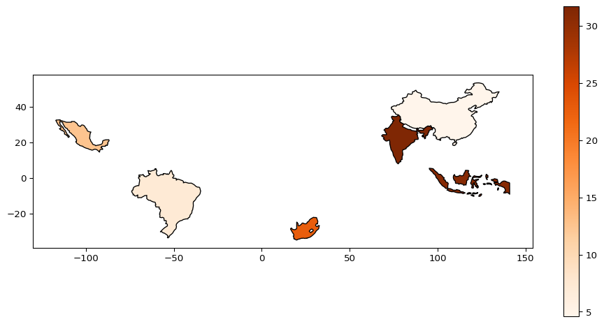

```python
import pandas as pd
import geopandas as gpd
import plotnine as p9

# Load cleaned data
data = pd.read_csv("cleaned_unicef_data_quarto.csv")
latest = data.sort_values('Year').groupby('Country').tail(1)

# Correct way: Load Natural Earth world shapefile from URL
world = gpd.read_file("https://naturalearth.s3.amazonaws.com/110m_cultural/ne_110m_admin_0_countries.zip")

# Merge on ADMIN instead of name
merged = world.merge(latest, how="left", left_on="ADMIN", right_on="Country")

# Plot
(merged.dropna(subset=["Facility_Value"])
 .plot(column='Facility_Value', cmap='Oranges', legend=True, edgecolor='black', figsize=(12,6)))
```

## **Visualisation 2: Bar Chart - Birth Rate Comparison**

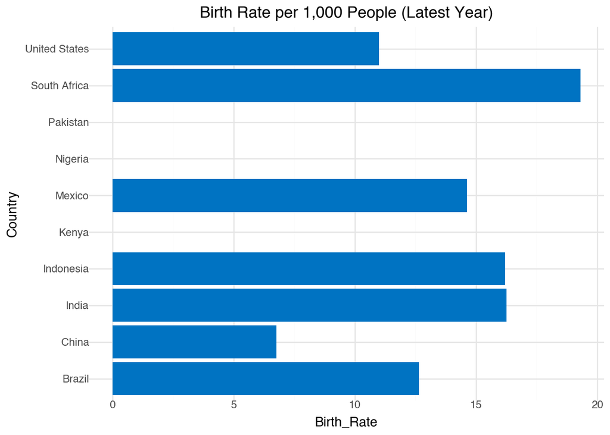

```python
(p9.ggplot(latest, p9.aes(x="Country", y="Birth_Rate")) +
 p9.geom_bar(stat="identity", fill="#0073C2FF") +
 p9.coord_flip() +
 p9.theme_minimal() +
 p9.ggtitle("Birth Rate per 1,000 People (Latest Year)"))
```

## **Visualisation 3: Scatter Plot - GDP vs Life Expectancy**

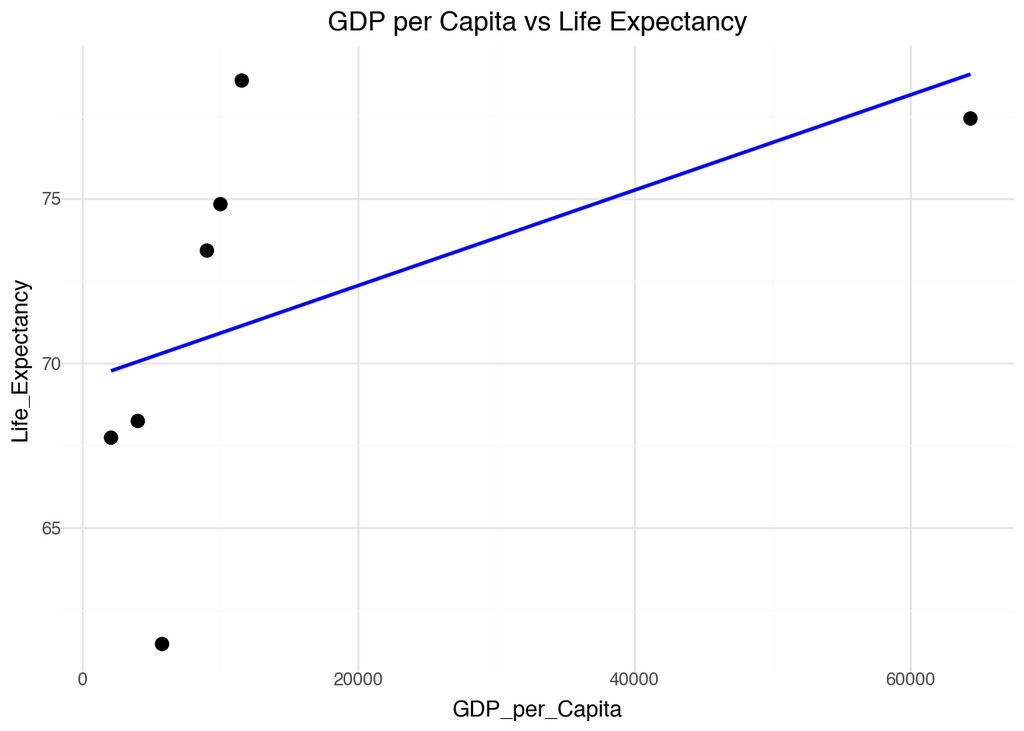

```python
(p9.ggplot(latest, p9.aes(x="GDP_per_Capita", y="Life_Expectancy", label="Country")) +
 p9.geom_point(size=3) +
 p9.geom_smooth(method="lm", se=False, color="blue") +
 p9.theme_minimal() +
 p9.ggtitle("GDP per Capita vs Life Expectancy"))
```

## **Visualisation 4: Time-Series - Stunting Trends Over Time**

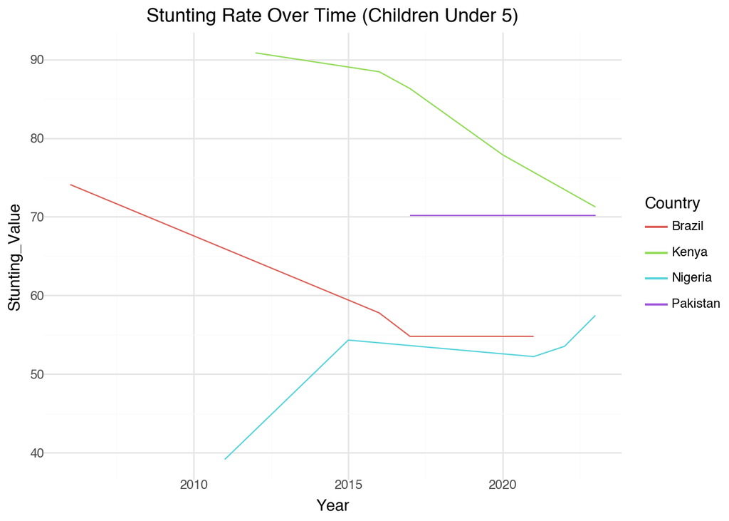

```python
(p9.ggplot(data.dropna(subset=["Stunting_Value"]), p9.aes(x="Year", y="Stunting_Value", color="Country")) +
 p9.geom_line() +
 p9.theme_minimal() +
 p9.ggtitle("Stunting Rate Over Time (Children Under 5)"))
```

## **Conclusion**

This analysis emphasizes: - Countries with higher GDP often enjoy better health outcomes. - Despite progress, stunting and limited healthcare access remain challenges, especially in low-income regions. - International attention and targeted interventions are needed to bridge these gaps and achieve UNICEF’s sustainable development goals.